# Salary Dataset Analysis (2020–2025)

End-to-End Machine Learning Pipeline: Regression, Classification & Insights

Data Science Report

2026-04-06

# 1 Introduction

This report presents a machine learning pipeline for analyzing and modeling salary trends from 2020-2025.Salaries are reported in USD(converted at average FX rates). The analysis covers data preprocessing,exploratory analysis, feature enginering, regression and classification modeling, statistical relationship analysis and some business relevant interpretation.

# 2 Data Understanding and Preprocessing

## 2.1 Load Libraries

```r
libs <- c("tidyverse", "dplyr", "gridExtra", "ggplot2", "ggfortify","broom", "ggcorrplot", "corrr", "corrplot",
          "MASS", 'datarium', 'randomForest', 'rpart', 'Hmisc', "caret", "Metrics","car","rpart.plot","e1071","pROC","kableExtra","scales")

for(lib in libs){
  if(!(lib %in% installed.packages())){
    install.packages(lib)
  }
  library(lib, character.only = TRUE)
}


theme_set(theme_classic())
```

```r
select  <- dplyr::select
mutate  <- dplyr::mutate
filter  <- dplyr::filter
summarise <- dplyr::summarise
```

## 2.2 Load and Inspect the Dataset

```r
df <-read_csv ("C:/Users/Light House/Desktop/MastersDSA/semThree-DSA/Linear Models/Data_Project/salaries.csv")
```

```r
#Display structure
str(df)
```

```
## spc_tbl_ [88,584 × 11] (S3: spec_tbl_df/tbl_df/tbl/data.frame)
##  $ work_year         : num [1:88584] 2025 2025 2025 2025 2025 ...
##  $ experience_level  : chr [1:88584] "MI" "SE" "SE" "SE" ...
##  $ employment_type   : chr [1:88584] "FT" "FT" "FT" "FT" ...
##  $ job_title         : chr [1:88584] "Customer Success Manager" "Engineer" "Engineer" "Applied Scientist" ...
##  $ salary            : num [1:88584] 57000 165000 109000 294000 137600 ...
##  $ salary_currency   : chr [1:88584] "EUR" "USD" "USD" "USD" ...
##  $ salary_in_usd     : num [1:88584] 60000 165000 109000 294000 137600 ...
##  $ employee_residence: chr [1:88584] "NL" "US" "US" "US" ...
##  $ remote_ratio      : num [1:88584] 50 0 0 0 0 0 0 0 0 0 ...
##  $ company_location  : chr [1:88584] "NL" "US" "US" "US" ...
##  $ company_size      : chr [1:88584] "L" "M" "M" "M" ...
##  - attr(*, "spec")=
##   .. cols(
##   ..   work_year = col_double(),
##   ..   experience_level = col_character(),
##   ..   employment_type = col_character(),
##   ..   job_title = col_character(),
##   ..   salary = col_double(),
##   ..   salary_currency = col_character(),
##   ..   salary_in_usd = col_double(),
##   ..   employee_residence = col_character(),
##   ..   remote_ratio = col_double(),
##   ..   company_location = col_character(),
##   ..   company_size = col_character()
##   .. )
##  - attr(*, "problems")=<externalptr>
```

```r
#Dimensions

cat("Dataset dimensions:", nrow(df), "rows x", ncol(df), "columns\n")
```

```
## Dataset dimensions: 88584 rows x 11 columns
```

```r
#First few rows
head(df)
```

```
## # A tibble: 6 × 11
##   work_year experience_level employment_type job_title    salary salary_currency
##       <dbl> <chr>            <chr>           <chr>         <dbl> <chr>
## 1      2025 MI               FT              Customer Su…  57000 EUR
## 2      2025 SE               FT              Engineer     165000 USD
## 3      2025 SE               FT              Engineer     109000 USD
## 4      2025 SE               FT              Applied Sci… 294000 USD
## 5      2025 SE               FT              Applied Sci… 137600 USD
## 6      2025 EN               FT              Data Analyst  82000 USD
## # ℹ 5 more variables: salary_in_usd <dbl>, employee_residence <chr>,
## #   remote_ratio <dbl>, company_location <chr>, company_size <chr>
```

## 2.3 Missing Values Check

```r
# checking for missing values in each column

missing_summary <- data.frame(
  Column = names(df),
  Missing_Count = sapply(df, function(x) sum(is.na(x))),
  Missing_Pct = sapply(df, function(x) round(mean(is.na(x)) * 100, 2))
)
row.names(missing_summary)<- NULL

cat("Total missing values:", sum(is.na(df)), "\n")
```

```
## Total missing values: 0
```

## 2.4 Convert Categorical Variables to Factors

This step converts text-based columns ( `experience_level`, `company_size`, `job_title`) from plain character strings into R **factors**, which are R’s way of representing categorical data. This is necessary because R’s modeling and plotting functions require factors to properly create dummy variables, group data and interpret categories correctly.

```r
## Convert Categorical Variables to Factors

categorical_cols <- c(
  "experience_level","employment_type","job_title","salary_currency","employee_residence","company_location","company_size"
)
df <- df %>%
  mutate(across(all_of(categorical_cols), as.factor))

# Convert (work_yea)r to factor for grouping keeping numeric copy for modeling

df$work_year_factor <- as.factor(df$work_year)

# Convert remote_ratio to factor for categorical analysis
df$remote_ratio_factor <- factor(df$remote_ratio,
  levels = c(0, 50, 100),
  labels = c("On-site", "Hybrid", "Remote")
)

# Verify conversions
str(df %>% select(all_of(categorical_cols), work_year_factor, remote_ratio_factor))
```

```
## tibble [88,584 × 9] (S3: tbl_df/tbl/data.frame)
##  $ experience_level   : Factor w/ 4 levels "EN","EX","MI",..: 3 4 4 4 4 1 1 4 4 4 ...
##  $ employment_type    : Factor w/ 4 levels "CT","FL","FT",..: 3 3 3 3 3 3 3 3 3 3 ...
##  $ job_title          : Factor w/ 312 levels "Account Executive",..: 89 179 179 37 37 90 90 293 293 278 ...
##  $ salary_currency    : Factor w/ 26 levels "AUD","BRL","CAD",..: 8 25 25 25 25 25 25 25 25 25 ...
##  $ employee_residence : Factor w/ 96 levels "AD","AE","AM",..: 63 90 90 90 90 90 90 90 90 90 ...
##  $ company_location   : Factor w/ 90 levels "AD","AE","AM",..: 61 85 85 85 85 85 85 85 85 85 ...
##  $ company_size       : Factor w/ 3 levels "L","M","S": 1 2 2 2 2 2 2 1 1 2 ...
##  $ work_year_factor   : Factor w/ 6 levels "2020","2021",..: 6 6 6 6 6 6 6 6 6 6 ...
##  $ remote_ratio_factor: Factor w/ 3 levels "On-site","Hybrid",..: 2 1 1 1 1 1 1 1 1 1 ...
```

## 2.5 Sanity Checks:

The sanity check ensures that salary conversions to USD are reasonable. Any large discrepancies between `salary` and `salary_in_usd` for USD-denominated rows would indicate data quality issues.

### 2.5.1 Salary vs Salary in USD

```r
# Checkin if (salary) and (salary_in_usd) are consistent for USD denominated salaries
usd_salaries <- df %>%
  filter(salary_currency == "USD")

if (nrow(usd_salaries) > 0) {
  usd_salaries <- usd_salaries %>%
    mutate(
      diff = abs(salary - salary_in_usd),
      pct_diff = ifelse(salary > 0, (diff / salary) * 100, NA)
    )

  cat("For USD-denominated salaries:\n")

  cat("Mean absolute difference:", round(mean(usd_salaries$diff, na.rm = TRUE), 2), "\n")
  cat("Max absolute difference:", round(max(usd_salaries$diff, na.rm = TRUE), 2), "\n")
  cat(
    "Records with >1% difference:",
    sum(usd_salaries$pct_diff > 1, na.rm = TRUE), "\n"
  )
}
```

```
## For USD-denominated salaries:
## Mean absolute difference: 0
## Max absolute difference: 0
## Records with >1% difference: 0
```

```r
# Check for implausible salary values
cat("\nSalary in USD summary:\n")
```

```
##
## Salary in USD summary:
```

```r
summary(df$salary_in_usd)
```

```
##    Min. 1st Qu.  Median    Mean 3rd Qu.    Max.
##   15000  106097  146307  157568  198600  800000
```

```r
# Flag potential outliers extremely low or high.

cat("\nRecords with salary_in_usd < $10,000:", sum(df$salary_in_usd < 10000), "\n")
```

```
##
## Records with salary_in_usd < $10,000: 0
```

```r
cat("Records with salary_in_usd > $500,000:", sum(df$salary_in_usd > 500000), "\n")
```

```
## Records with salary_in_usd > $500,000: 194
```

# 3 Exploratory Data Analysis (EDA)

## 3.1 Descriptive Statistics

```r
# Summary statistics for numeric variables
numeric_vars <- df %>%
  select(work_year, salary, salary_in_usd, remote_ratio)

summary(numeric_vars) %>%
  kable(caption = "Descriptive Statistics – Numeric Variables") %>%
  kable_styling(bootstrap_options = c("striped", "hover"), full_width = FALSE)
```

Descriptive Statistics – Numeric Variables

|  | work_year | salary | salary_in_usd | remote_ratio |
| --- | --- | --- | --- | --- |
|  | Min. :2020 | Min. : 14000 | Min. : 15000 | Min. : 0.00 |
|  | 1st Qu.:2024 | 1st Qu.: 106000 | 1st Qu.:106097 | 1st Qu.: 0.00 |
|  | Median :2024 | Median : 147000 | Median :146307 | Median : 0.00 |
|  | Mean :2024 | Mean : 161932 | Mean :157568 | Mean : 21.29 |
|  | 3rd Qu.:2024 | 3rd Qu.: 199500 | 3rd Qu.:198600 | 3rd Qu.: 0.00 |
|  | Max. :2025 | Max. :30400000 | Max. :800000 | Max. :100.00 |

```r
# Frequency tables for key categorical variables

cat("Experience Level Distribution \n")
```

```
## Experience Level Distribution
```

```r
table(df$experience_level) %>%
  sort(decreasing = TRUE) %>%
  print()
```

```
##
##    SE    MI    EN    EX
## 51596 26748  8381  1859
```

```r
cat("\n Employment Type Distribution \n")
```

```
##
##  Employment Type Distribution
```

```r
table(df$employment_type) %>%
  sort(decreasing = TRUE) %>%
  print()
```

```
##
##    FT    PT    CT    FL
## 88111   233   224    16
```

```r
cat("\n Company Size Distribution \n")
```

```
##
##  Company Size Distribution
```

```r
table(df$company_size) %>%
  sort(decreasing = TRUE) %>%
  print()
```

```
##
##     M     L     S
## 85667  2703   214
```

```r
cat("\n Remote Ratio Distribution\n")
```

```
##
##  Remote Ratio Distribution
```

```r
table(df$remote_ratio_factor) %>%
  sort(decreasing = TRUE) %>%
  print()
```

```
##
## On-site  Remote  Hybrid
##   69580   18708     296
```

```r
# Top 10 most common job titles

cat("\n Top 10 Job Titles \n")
```

```
##
##  Top 10 Job Titles
```

```r
df %>%
  count(job_title, sort = TRUE) %>%
  head(10) %>%
  print()
```

```
## # A tibble: 10 × 2
##    job_title                     n
##    <fct>                     <int>
##  1 Data Scientist            13156
##  2 Data Engineer             10883
##  3 Software Engineer          9596
##  4 Data Analyst               8652
##  5 Machine Learning Engineer  6443
##  6 Engineer                   5344
##  7 Manager                    3488
##  8 Research Scientist         2553
##  9 Analyst                    2066
## 10 Applied Scientist          1778
```

## 3.2 Salary Distribution

Salary distributions are typically right-skewed with a long tail of high earners.

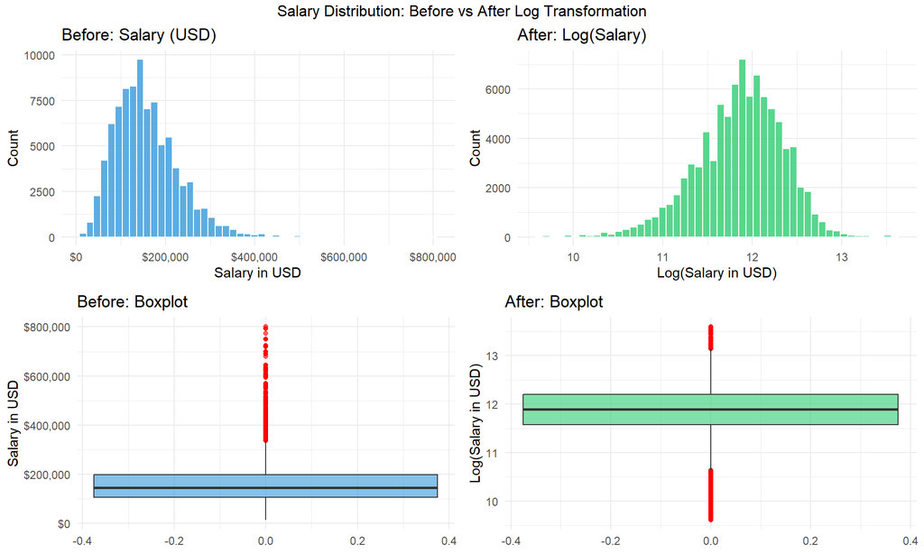

```r
# NEW CODE
# Before transformation – Histogram
p1 <- ggplot(df, aes(x = salary_in_usd)) +
  geom_histogram(bins = 50, fill = "#3498db", color = "white", alpha = 0.8) +
  scale_x_continuous(labels = dollar_format()) +
  labs(title = "Before: Salary (USD)", x = "Salary in USD", y = "Count") +
  theme_minimal()

# After transformation – Histogram
p2 <- ggplot(df %>% filter(salary_in_usd > 0), aes(x = log(salary_in_usd))) +
  geom_histogram(bins = 50, fill = "#2ecc71", color = "white", alpha = 0.8) +
  labs(title = "After: Log(Salary)", x = "Log(Salary in USD)", y = "Count") +
  theme_minimal()

# Before transformation – Boxplot
p3 <- ggplot(df, aes(y = salary_in_usd)) +
  geom_boxplot(fill = "#3498db", alpha = 0.6, outlier.color = "red") +
  scale_y_continuous(labels = dollar_format()) +
  labs(title = "Before: Boxplot", y = "Salary in USD") +
  theme_minimal()

# After transformation – Boxplot
p4 <- ggplot(df %>% filter(salary_in_usd > 0), aes(y = log(salary_in_usd))) +
  geom_boxplot(fill = "#2ecc71", alpha = 0.6, outlier.color = "red") +
  labs(title = "After: Boxplot", y = "Log(Salary in USD)") +
  theme_minimal()

# Arrange in 2x2 grid
grid.arrange(p1, p2, p3, p4, ncol = 2, nrow = 2,
             top = "Salary Distribution: Before vs After Log Transformation")
```

```r
# Print skewness comparison
cat("Skewness BEFORE transformation:", round(skewness(df$salary_in_usd), 3), "\n")
```

```
## Skewness BEFORE transformation: 1.322
```

```r
cat("Skewness AFTER transformation:",
    round(skewness(log(df$salary_in_usd[df$salary_in_usd > 0])), 3), "\n")
```

```
## Skewness AFTER transformation: -0.518
```

The top row shows histograms before vs after and the bottom row shows boxplots before vs after. The green plots on the right should look much more symmetric and bell-shaped than the blue ones on the left, with the skewness values confirming the improvement numerically.

## 3.3 Salary vs Experience Level

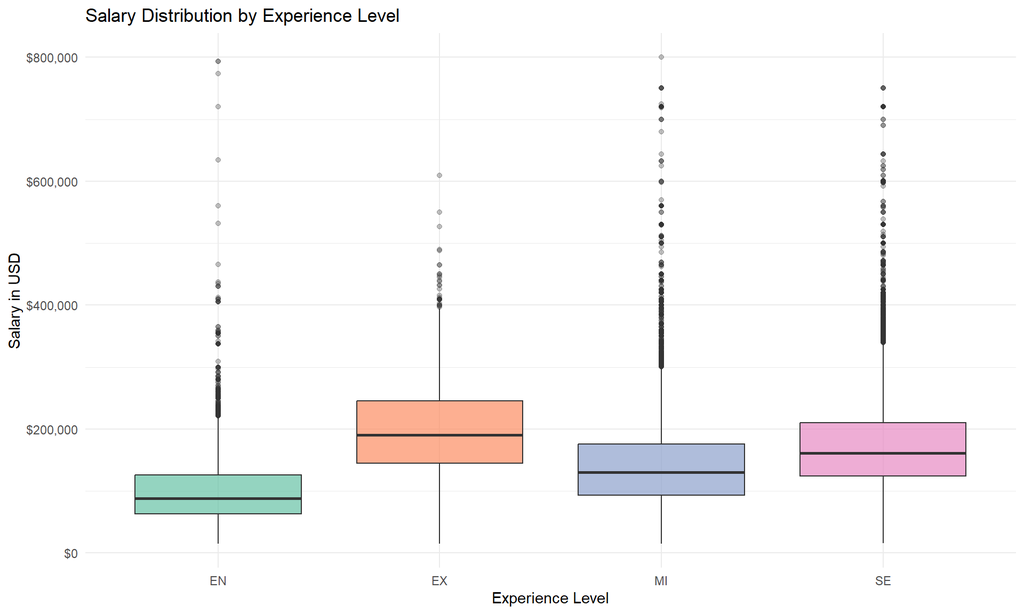

```r
ggplot(df, aes(x = experience_level, y = salary_in_usd, fill = experience_level)) +
  geom_boxplot(alpha = 0.7, outlier.alpha = 0.3) +
  scale_y_continuous(labels = dollar_format()) +
  scale_fill_brewer(palette = "Set2") +
  labs(
    title = "Salary Distribution by Experience Level",
    x = "Experience Level", y = "Salary in USD"
  ) +
  theme_minimal() +
  theme(legend.position = "none")
```

```r
# Summary table
df %>%
  group_by(experience_level) %>%
  summarise(
    Count = n(),
    Mean_Salary = round(mean(salary_in_usd), 0),
    Median_Salary = round(median(salary_in_usd), 0),
    SD_Salary = round(sd(salary_in_usd), 0)
  ) %>%
  arrange(desc(Mean_Salary)) %>%
  kable(
    caption = "Salary Summary by Experience Level",
    format.args = list(big.mark = ",")
  ) %>%
  kable_styling(bootstrap_options = c("striped", "hover"), full_width = FALSE)
```

Salary Summary by Experience Level

| experience_level | Count | Mean_Salary | Median_Salary | SD_Salary |
| --- | --- | --- | --- | --- |
| EX | 1,859 | 200,224 | 190,000 | 77,122 |
| SE | 51,596 | 173,034 | 161,300 | 70,307 |
| MI | 26,748 | 142,709 | 130,000 | 71,620 |
| EN | 8,381 | 100,316 | 87,943 | 56,311 |

Salary increases consistently with experience level, with Executive (EX) roles earning the highest and Entry-level (EN) the lowest. The salary spread also widens at senior levels that indicating more variability in compensation for experienced professionals. This confirms that experience level is a strong predictor of salary.

## 3.4 Salary vs Company Size

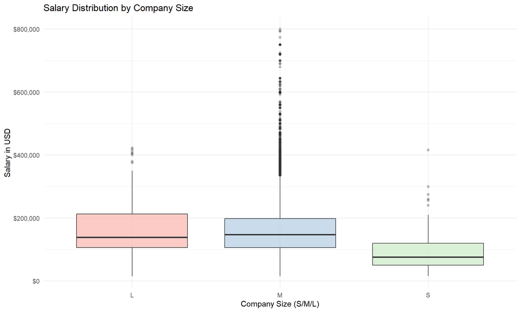

```r
ggplot(df, aes(x = company_size, y = salary_in_usd, fill = company_size)) +
  geom_boxplot(alpha = 0.7, outlier.alpha = 0.3) +
  scale_y_continuous(labels = dollar_format()) +
  scale_fill_brewer(palette = "Pastel1") +
  labs(
    title = "Salary Distribution by Company Size",
    x = "Company Size (S/M/L)", y = "Salary in USD"
  ) +
  theme_minimal() +
  theme(legend.position = "none")
```

```r
df %>%
  group_by(company_size) %>%
  summarise(
    Count = n(),
    Mean_Salary = round(mean(salary_in_usd), 0),
    Median_Salary = round(median(salary_in_usd), 0)
  ) %>%
  kable(
    caption = "Salary by Company Size",
    format.args = list(big.mark = ",")
  ) %>%
  kable_styling(bootstrap_options = c("striped", "hover"), full_width = FALSE)
```

Salary by Company Size

| company_size | Count | Mean_Salary | Median_Salary |
| --- | --- | --- | --- |
| L | 2,703 | 154,475 | 139,100 |
| M | 85,667 | 157,835 | 147,000 |
| S | 214 | 89,773 | 76,078 |

Medium (M) and Large (L) companies tend to offer higher salaries compared to Small (S) companies with medium sized firms often showing the widest salary range. Small companies cluster at lower pay levels with less variation likely due to tighter budgets and fewer senior roles. Overall, company size has a noticeable but moderate effect on compensation.

## 3.5 Salary vs Remote Ratio

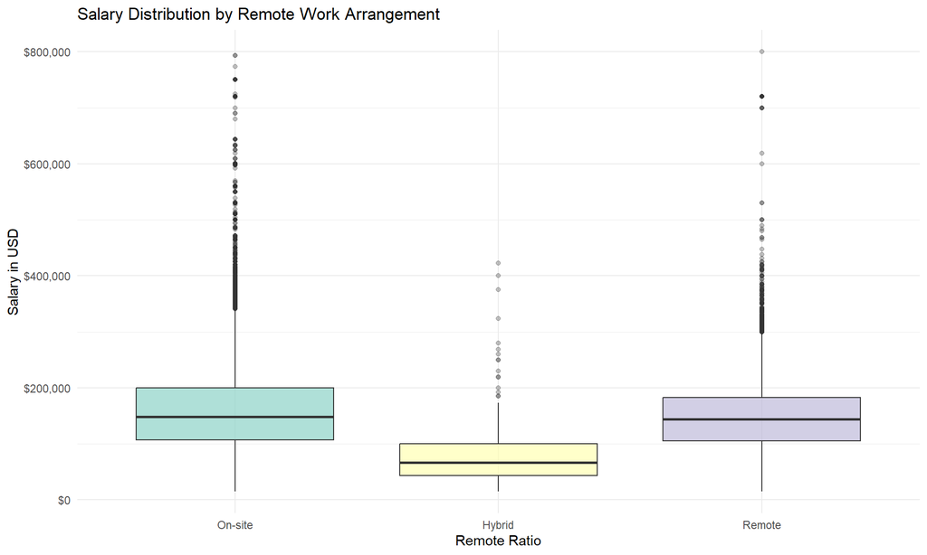

```r
ggplot(df, aes(
  x = remote_ratio_factor, y = salary_in_usd,
  fill = remote_ratio_factor
)) +
  geom_boxplot(alpha = 0.7, outlier.alpha = 0.3) +
  scale_y_continuous(labels = dollar_format()) +
  scale_fill_brewer(palette = "Set3") +
  labs(
    title = "Salary Distribution by Remote Work Arrangement",
    x = "Remote Ratio", y = "Salary in USD"
  ) +
  theme_minimal() +
  theme(legend.position = "none")
```

```r
df %>%
  group_by(remote_ratio_factor) %>%
  summarise(
    Count = n(),
    Mean_Salary = round(mean(salary_in_usd), 0),
    Median_Salary = round(median(salary_in_usd), 0)
  ) %>%
  kable(
    caption = "Salary by Remote Work Arrangement",
    format.args = list(big.mark = ",")
  ) %>%
  kable_styling(bootstrap_options = c("striped", "hover"), full_width = FALSE)
```

Salary by Remote Work Arrangement

| remote_ratio_factor | Count | Mean_Salary | Median_Salary |
| --- | --- | --- | --- |
| On-site | 69,580 | 160,196 | 148,000 |
| Hybrid | 296 | 81,255 | 66,666 |
| Remote | 18,708 | 148,999 | 143,709 |

## 3.6 Salary Trends Across Years (2020–2025)

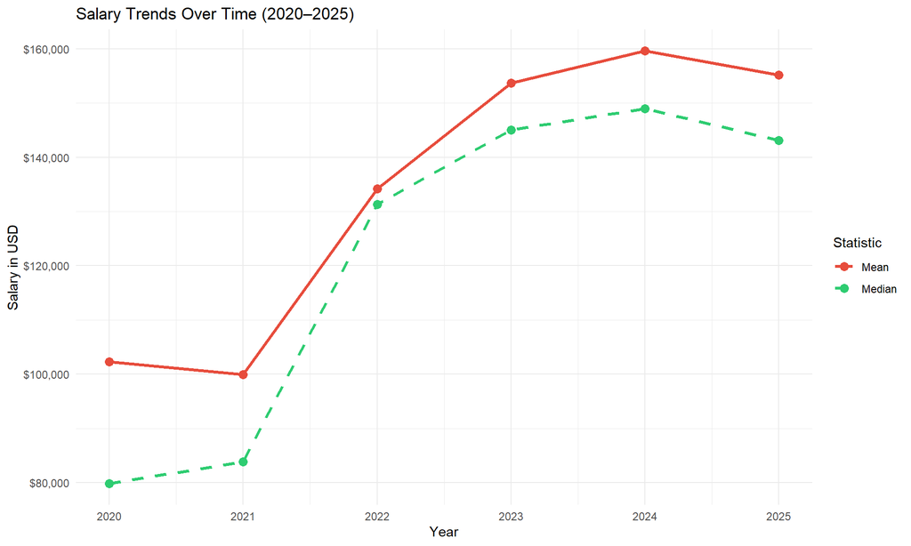

```r
yearly_stats <- df %>%
  group_by(work_year) %>%
  summarise(
    Count = n(),
    Mean_Salary = mean(salary_in_usd),
    Median_Salary = median(salary_in_usd),
    SD_Salary = sd(salary_in_usd)
  )

ggplot(yearly_stats, aes(x = work_year)) +
  geom_line(aes(y = Mean_Salary, color = "Mean"), linewidth = 1.2) +
  geom_point(aes(y = Mean_Salary, color = "Mean"), size = 3) +
  geom_line(aes(y = Median_Salary, color = "Median"),
    linewidth = 1.2,
    linetype = "dashed"
  ) +
  geom_point(aes(y = Median_Salary, color = "Median"), size = 3) +
  scale_y_continuous(labels = dollar_format()) +
  scale_color_manual(values = c("Mean" = "#e74c3c", "Median" = "#2ecc71")) +
  labs(
    title = "Salary Trends Over Time (2020–2025)",
    x = "Year", y = "Salary in USD", color = "Statistic"
  ) +
  theme_minimal()
```

```r
yearly_stats %>%
  mutate(across(
    where(is.numeric) & !matches("work_year|Count"),
    ~ round(., 0)
  )) %>%
  kable(
    caption = "Yearly Salary Statistics",
    format.args = list(big.mark = ",")
  ) %>%
  kable_styling(bootstrap_options = c("striped", "hover"), full_width = FALSE)
```

Yearly Salary Statistics

| work_year | Count | Mean_Salary | Median_Salary | SD_Salary |
| --- | --- | --- | --- | --- |
| 2,020 | 75 | 102,251 | 79,833 | 82,722 |
| 2,021 | 218 | 99,922 | 83,872 | 67,072 |
| 2,022 | 1,660 | 134,175 | 131,300 | 57,775 |
| 2,023 | 8,522 | 153,701 | 145,000 | 65,387 |
| 2,024 | 62,234 | 159,600 | 148,955 | 73,581 |
| 2,025 | 15,875 | 155,175 | 143,100 | 77,858 |

## 3.7 Outlier Analysis

```r
Q1 <- quantile(df$salary_in_usd, 0.25)
Q3 <- quantile(df$salary_in_usd, 0.75)
IQR_val <- Q3 - Q1
lower_bound <- Q1 - 1.5 * IQR_val
upper_bound <- Q3 + 1.5 * IQR_val

outliers <- df %>%
  filter(salary_in_usd < lower_bound | salary_in_usd > upper_bound)

cat("IQR:", scales::dollar(IQR_val), "\n")
```

```
## IQR: $92,502.75
```

```r
cat("Lower bound:", scales::dollar(lower_bound), "\n")
```

```
## Lower bound: -$32,656.88
```

```r
cat("Upper bound:", scales::dollar(upper_bound), "\n")
```

```
## Upper bound: $337,354
```

```r
cat(
  "Number of outliers:", nrow(outliers),
  "(", round(nrow(outliers) / nrow(df) * 100, 1), "% of data)\n"
)
```

```
## Number of outliers: 1750 ( 2 % of data)
```

```r
# Distribution of outliers by experience level
if (nrow(outliers) > 0) {
  cat("\nOutliers by Experience Level:\n")
  table(outliers$experience_level) %>% print()
}
```

```
##
## Outliers by Experience Level:
##
##   EN   EX   MI   SE
##   45  105  439 1161
```

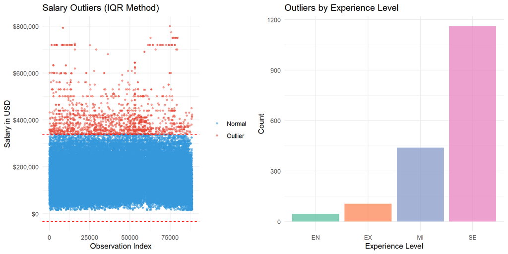

```r
# NEW CODE
# Create a temporary dataframe with outlier flag
df_outlier <- df %>%
  mutate(outlier_flag = ifelse(
    salary_in_usd < lower_bound | salary_in_usd > upper_bound,
    "Outlier", "Normal"
  ))

# Plot 1: Scatter plot highlighting outliers
p1 <- ggplot(df_outlier, aes(x = seq_along(salary_in_usd), y = salary_in_usd,
                              color = outlier_flag)) +
  geom_point(alpha = 0.5, size = 1) +
  geom_hline(yintercept = upper_bound, linetype = "dashed", color = "red") +
  geom_hline(yintercept = lower_bound, linetype = "dashed", color = "red") +
  scale_y_continuous(labels = dollar_format()) +
  scale_color_manual(values = c("Normal" = "#3498db", "Outlier" = "#e74c3c")) +
  labs(title = "Salary Outliers (IQR Method)",
       x = "Observation Index", y = "Salary in USD", color = "") +
  theme_minimal()

# Plot 2: Outlier distribution by experience level
outlier_data <- df_outlier %>% filter(outlier_flag == "Outlier")

p2 <- ggplot(outlier_data, aes(x = experience_level, fill = experience_level)) +
  geom_bar(alpha = 0.8) +
  scale_fill_brewer(palette = "Set2") +
  labs(title = "Outliers by Experience Level",
       x = "Experience Level", y = "Count") +
  theme_minimal() +
  theme(legend.position = "none")

grid.arrange(p1, p2, ncol = 2)
```

# 4 Feature Engineering

```r
# Create a working copy for modeling
df_model <- df

# Feature 1: Salary Bands (for classification)
# Justification: Converting continuous salary into ordered categories enables
# classification modeling and makes predictions more interpretable for HR teams.

salary_quartiles <- quantile(df_model$salary_in_usd, probs = c(0.25, 0.50, 0.75))

df_model <- df_model %>%
  mutate(salary_band = case_when(
    salary_in_usd <= salary_quartiles[1] ~ "Low",
    salary_in_usd <= salary_quartiles[2] ~ "Medium",
    salary_in_usd <= salary_quartiles[3] ~ "High",
    TRUE ~ "Very High"
  ))

df_model$salary_band <- factor(df_model$salary_band,
  levels = c("Low", "Medium", "High", "Very High"),
  ordered = TRUE
)

cat("Salary Band Distribution:\n")
```

```
## Salary Band Distribution:
```

```r
table(df_model$salary_band) %>% print()
```

```
##
##       Low    Medium      High Very High
##     22146     22148     22156     22134
```

```r
cat("Quartile cutoffs:", scales::dollar(salary_quartiles), "\n")
```

```
## Quartile cutoffs: $106,097 $146,307 $198,600
```

```r
# Feature 2: Experience Hierarchy (ordinal encoding)
# Justification: Experience level has a natural order (EN < MI < SE < EX),
# and ordinal encoding preserves this hierarchy for models.

df_model <- df_model %>%
  mutate(experience_ord = case_when(
    experience_level == "EN" ~ 1,
    experience_level == "MI" ~ 2,
    experience_level == "SE" ~ 3,
    experience_level == "EX" ~ 4
  ))

cat("\nExperience ordinal mapping: EN=1, MI=2, SE=3, EX=4\n")
```

```
##
## Experience ordinal mapping: EN=1, MI=2, SE=3, EX=4
```

```r
# Feature 3: Remote Work Category
# Justification: The remote_ratio (0/50/100) is already transformed to a factor
# above. Here we also create a binary is_remote flag for simpler modeling.

df_model <- df_model %>%
  mutate(is_remote = ifelse(remote_ratio == 100, 1, 0))

cat("Is Remote distribution:\n")
```

```
## Is Remote distribution:
```

```r
table(df_model$is_remote) %>% print()
```

```
##
##     0     1
## 69876 18708
```

```r
# Feature 4:Experience × Company Size
# Justification: Salary may depend on the combination of seniority and company
# scale (e.g senior roles at large companies may pay disproportionately more).


df_model <- df_model %>%
  mutate(
    company_size_num = case_when(
      company_size == "S" ~ 1,
      company_size == "M" ~ 2,
      company_size == "L" ~ 3
    ),
    exp_x_compsize = experience_ord * company_size_num
  )
```

```r
# Feature 5: Regional Grouping
# Justification-With many unique country codes, grouping into regions reduces
# dimensionality while preserving geographic salary patterns.

df_model <- df_model %>%
  mutate(company_region = case_when(
    company_location == "US" ~ "US",
    company_location == "GB" ~ "UK",
    company_location %in% c(
      "DE", "FR", "ES", "NL", "PT", "IT",
      "AT", "BE", "CH", "SE", "DK", "FI",
      "NO", "IE", "PL", "CZ", "RO", "GR",
      "HU", "LU"
    ) ~ "Europe",
    company_location %in% c("CA", "BR", "MX", "AR", "CO", "CL") ~ "Americas",
    company_location %in% c(
      "IN", "PK", "SG", "JP", "CN", "KR",
      "AU", "NZ", "IL", "AE", "TR"
    ) ~ "Asia-Pacific",
    TRUE ~ "Other"
  ))

df_model$company_region <- as.factor(df_model$company_region)

cat("\nCompany Region Distribution:\n")
```

```
##
## Company Region Distribution:
```

```r
table(df_model$company_region) %>%
  sort(decreasing = TRUE) %>%
  print()
```

```
##
##           US     Americas           UK       Europe        Other Asia-Pacific
##        79762         3464         2584         1484          717          573
```

```r
# ---------- Feature 6: Same Country Flag ----------
# Justification: Whether employee and company are in the same country may
# affect compensation (cross-border roles may pay differently).
df_model <- df_model %>%
  mutate(same_country = ifelse(
    as.character(employee_residence) == as.character(company_location), 1, 0
  ))

cat("\nSame Country (employee = company location):\n")
```

```
##
## Same Country (employee = company location):
```

```r
table(df_model$same_country) %>% print()
```

```
##
##     0     1
##   147 88437
```

This code creates a binary flag (1 or 0) that checks whether the employee lives in the same country as their company. If `employee_residence` matches `company_location`, it assigns 1 (same country), otherwise 0 (cross-border).Basically this feature is that cross-border employees (where `same_country = 0`) may receive different compensation.

```r
# Feature 7: Log Salary
# Justification: Salary is right-skewed; log transformation helps meet
# linear regression assumptions and stabilizes variance.


df_model <- df_model %>%
  mutate(log_salary = log(salary_in_usd))

cat("\nFeature engineering complete. New columns added:\n")
```

```
##
## Feature engineering complete. New columns added:
```

```r
cat("salary_band, experience_ord, is_remote, company_size_num,\n")
```

```
## salary_band, experience_ord, is_remote, company_size_num,
```

```r
cat("exp_x_compsize, company_region, same_country, log_salary\n")
```

```
## exp_x_compsize, company_region, same_country, log_salary
```

This code applies the natural logarithm (`log()`) to `salary_in_usd` and stores it as a new column called `log_salary`. This is done because salary data is typically right-skewed because most people earn moderate salaries while a few earn extremely high amounts, pulling the distribution’s tail to the right. Log transformation compresses those extreme values and makes the distribution more symmetric and bell-shaped, which helps linear regression meet its assumptions of normally distributed residuals and constant variance.

# 5 Regression Modeling (Predict Salary)

## 5.1 Prepare Data for Modeling

```r
# Select features for regression
reg_features <- c(
  "experience_ord", "company_size_num", "is_remote",
  "work_year", "exp_x_compsize", "same_country",
  "company_region"
)

# Create model dataframe:remove rows with NA if any
df_reg <- df_model %>%
  select(all_of(reg_features), salary_in_usd, log_salary) %>%
  drop_na()

cat("Regression dataset:", nrow(df_reg), "rows\n")
```

```
## Regression dataset: 88584 rows
```

```r
# Train-test split (80/20)
set.seed(42)
train_index <- createDataPartition(df_reg$salary_in_usd, p = 0.8, list = FALSE)
train_data <- df_reg[train_index, ]
test_data <- df_reg[-train_index, ]

cat("Training set:", nrow(train_data), "rows\n")
```

```
## Training set: 70869 rows
```

```r
cat("Test set:", nrow(test_data), "rows\n")
```

```
## Test set: 17715 rows
```

## 5.2 Baseline Linear Regression Model

```r
# Fit baseline linear regression on raw salary_in_usd
baseline_lm <- lm(
  salary_in_usd ~ experience_ord + company_size_num +
    is_remote + work_year + company_region + same_country,
  data = train_data
)

summary(baseline_lm)
```

```
##
## Call:
## lm(formula = salary_in_usd ~ experience_ord + company_size_num +
##     is_remote + work_year + company_region + same_country, data = train_data)
##
## Residuals:
##     Min      1Q  Median      3Q     Max
## -170848  -45565  -10565   32999  741735
##
## Coefficients:
##                              Estimate Std. Error t value Pr(>|t|)
## (Intercept)                -6327022.4   839869.2  -7.533 5.00e-14 ***
## experience_ord                31782.2      368.3  86.301  < 2e-16 ***
## company_size_num               4868.9     1417.5   3.435 0.000593 ***
## is_remote                    -14753.6      627.1 -23.527  < 2e-16 ***
## work_year                      3135.3      415.1   7.553 4.30e-14 ***
## company_regionAsia-Pacific   -14874.8     3378.8  -4.402 1.07e-05 ***
## company_regionEurope         -37738.6     2337.1 -16.148  < 2e-16 ***
## company_regionOther          -58067.0     3082.9 -18.835  < 2e-16 ***
## company_regionUK             -30119.2     1951.7 -15.432  < 2e-16 ***
## company_regionUS              30996.2     1305.1  23.751  < 2e-16 ***
## same_country                  25724.6     6330.3   4.064 4.83e-05 ***
## ---
## Signif. codes:  0 '***' 0.001 '**' 0.01 '*' 0.05 '.' 0.1 ' ' 1
##
## Residual standard error: 67290 on 70858 degrees of freedom
## Multiple R-squared:  0.1609, Adjusted R-squared:  0.1608
## F-statistic:  1359 on 10 and 70858 DF,  p-value: < 2.2e-16
```

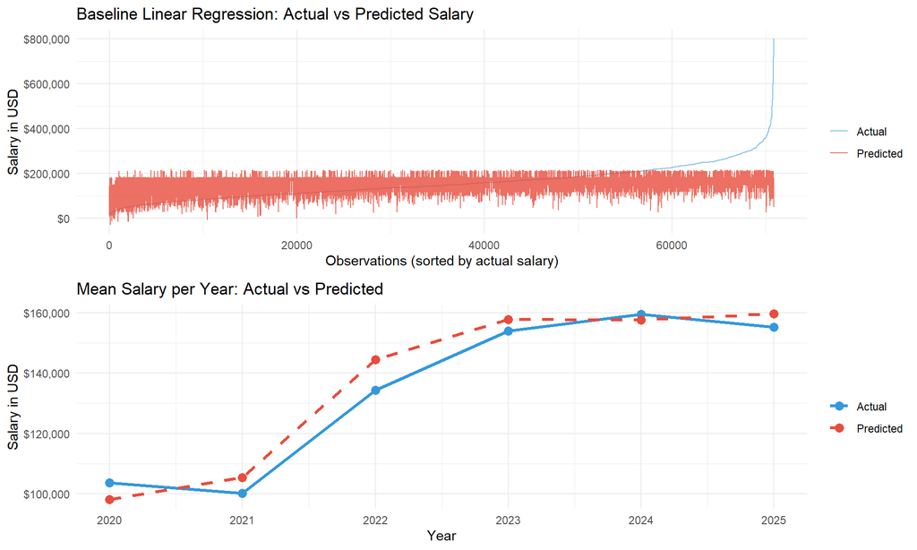

```r
# Get predictions on training data
train_data$predicted <- predict(baseline_lm, newdata = train_data)

# Plot 1: Actual vs Predicted line graph (sorted by actual salary)
plot_df <- train_data %>%
  arrange(salary_in_usd) %>%
  mutate(index = row_number())

p1 <- ggplot(plot_df, aes(x = index)) +
  geom_line(aes(y = salary_in_usd, color = "Actual"), alpha = 0.6) +
  geom_line(aes(y = predicted, color = "Predicted"), alpha = 0.8) +
  scale_y_continuous(labels = dollar_format()) +
  scale_color_manual(values = c("Actual" = "#3498db", "Predicted" = "#e74c3c")) +
  labs(title = "Baseline Linear Regression: Actual vs Predicted Salary",
       x = "Observations (sorted by actual salary)",
       y = "Salary in USD", color = "") +
  theme_minimal()

# Plot 2: Predicted salary trend across years
yearly_pred <- train_data %>%
  group_by(work_year) %>%
  summarise(
    Mean_Actual = mean(salary_in_usd),
    Mean_Predicted = mean(predicted)
  )

p2 <- ggplot(yearly_pred, aes(x = work_year)) +
  geom_line(aes(y = Mean_Actual, color = "Actual"), linewidth = 1.2) +
  geom_point(aes(y = Mean_Actual, color = "Actual"), size = 3) +
  geom_line(aes(y = Mean_Predicted, color = "Predicted"),
            linewidth = 1.2, linetype = "dashed") +
  geom_point(aes(y = Mean_Predicted, color = "Predicted"), size = 3) +
  scale_y_continuous(labels = dollar_format()) +
  scale_color_manual(values = c("Actual" = "#3498db", "Predicted" = "#e74c3c")) +
  labs(title = "Mean Salary per Year: Actual vs Predicted",
       x = "Year", y = "Salary in USD", color = "") +
  theme_minimal()

grid.arrange(p1, p2, nrow = 2)
```

```r
# Clean up temporary column
train_data$predicted <- NULL
```

**Plot 1 (top):** Shows every observation sorted by actual salary: the blue line is the real salary and the red line is what the model predicted. The closer the two lines overlap, the better the model fits. Large gaps reveal where the model struggles, typically at very high salaries.

**Plot 2 (bottom):** Compares the average actual vs predicted salary per year. If the red line closely follows the blue line, the model is capturing the yearly salary trend well.

## 5.3 Assumption Checking

### 5.3.1 Linearity & Homoscedasticity

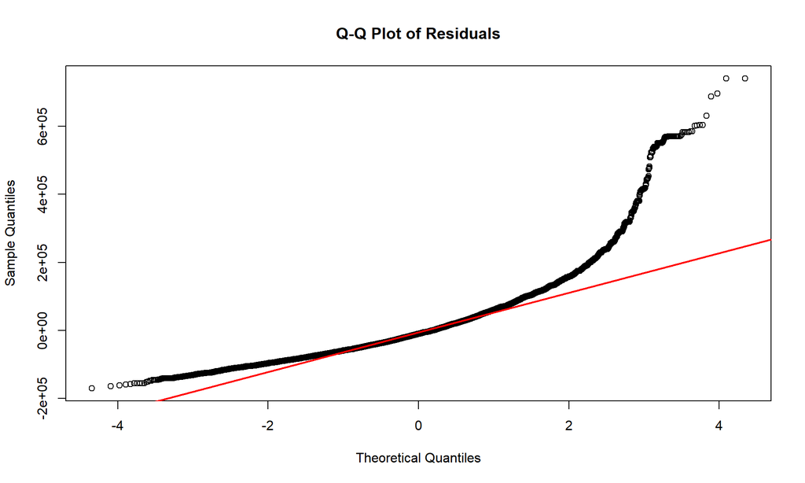

[output not shown]

```r
# QQ plot of residuals from baseline linear regression

qqnorm(residuals(baseline_lm), main = "Q-Q Plot of Residuals")

qqline(residuals(baseline_lm), col = "red", lwd = 2)
```

### 5.3.2 Multicollinearity (VIF)

```r
vif_values <- vif(baseline_lm)

# Extract raw GVIF values no adjustment
vif_df <- data.frame(
  Feature = rownames(vif_values),
  VIF = round(vif_values[, "GVIF"], 2)
)

# Table
vif_df %>%
  arrange(desc(VIF)) %>%
  kable(caption = "VIF Values (> 5 indicates multicollinearity concern)") %>%
  kable_styling(bootstrap_options = c("striped", "hover"), full_width = FALSE)
```

VIF Values (> 5 indicates multicollinearity concern)

|  | Feature | VIF |
| --- | --- | --- |
| work_year | work_year | 1.04 |
| is_remote | is_remote | 1.03 |
| company_region | company_region | 1.03 |
| same_country | same_country | 1.03 |
| experience_ord | experience_ord | 1.02 |
| company_size_num | company_size_num | 1.01 |

```r
cat("Features with VIF > 5:", sum(vif_df$VIF > 5), "\n")
```

```
## Features with VIF > 5: 0
```

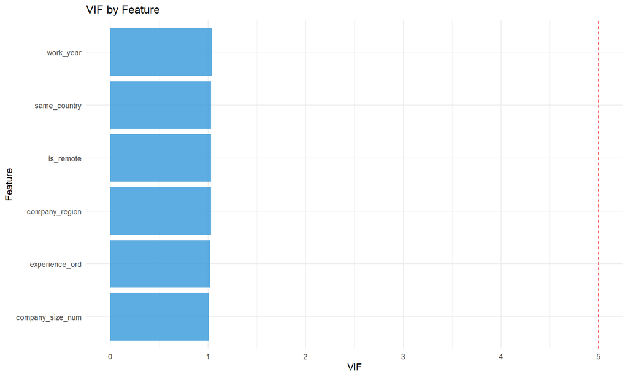

```r
# Bar plot
ggplot(vif_df, aes(x = reorder(Feature, VIF), y = VIF)) +
  geom_bar(stat = "identity", fill = "#3498db", alpha = 0.8) +
  geom_hline(yintercept = 5, linetype = "dashed", color = "red") +
  coord_flip() +
  labs(title = "VIF by Feature", x = "Feature", y = "VIF") +
  theme_minimal()
```

This uses the raw GVIF column directly with the standard rule: anything above 5 the red dashed line signals multicollinearity concern.

## 5.4 Log-Transformed Regression Model

```r
# Fit model on log-transformed salary to address skewness and heteroscedasticity

# Log-transformed linear regression model
log_lm <- lm(
  log_salary ~ experience_ord + company_size_num +
    is_remote + work_year + exp_x_compsize +
    company_region + same_country,
  data = train_data
)

# Model summary
summary(log_lm)
```

```
##
## Call:
## lm(formula = log_salary ~ experience_ord + company_size_num +
##     is_remote + work_year + exp_x_compsize + company_region +
##     same_country, data = train_data)
##
## Residuals:
##      Min       1Q   Median       3Q      Max
## -2.35856 -0.27522  0.01146  0.27945  2.67289
##
## Coefficients:
##                              Estimate Std. Error t value Pr(>|t|)
## (Intercept)                -21.539140   5.184847  -4.154 3.27e-05 ***
## experience_ord               0.265857   0.025086  10.598  < 2e-16 ***
## company_size_num             0.064485   0.030353   2.125   0.0336 *
## is_remote                   -0.087695   0.003871 -22.653  < 2e-16 ***
## work_year                    0.015874   0.002563   6.193 5.92e-10 ***
## exp_x_compsize              -0.010307   0.012336  -0.835   0.4035
## company_regionAsia-Pacific  -0.234014   0.020857 -11.220  < 2e-16 ***
## company_regionEurope        -0.422007   0.014426 -29.252  < 2e-16 ***
## company_regionOther         -0.759293   0.019032 -39.895  < 2e-16 ***
## company_regionUK            -0.331667   0.012048 -27.529  < 2e-16 ***
## company_regionUS             0.231431   0.008056  28.727  < 2e-16 ***
## same_country                 0.352173   0.039081   9.011  < 2e-16 ***
## ---
## Signif. codes:  0 '***' 0.001 '**' 0.01 '*' 0.05 '.' 0.1 ' ' 1
##
## Residual standard error: 0.4153 on 70857 degrees of freedom
## Multiple R-squared:  0.2632, Adjusted R-squared:  0.2631
## F-statistic:  2301 on 11 and 70857 DF,  p-value: < 2.2e-16
```

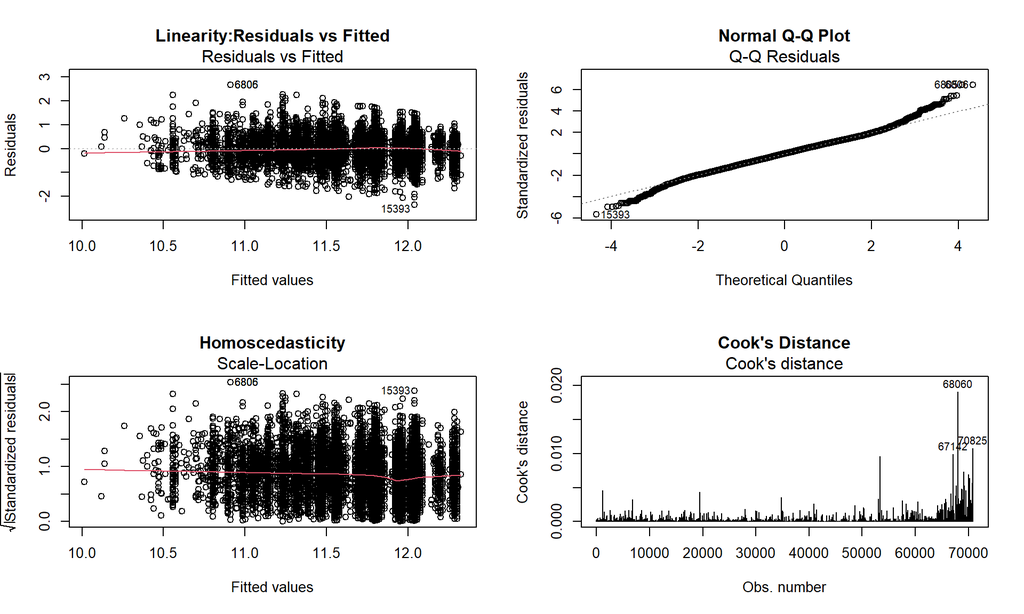

```r
# Diagnostic plots (one at a time for clarity)
par(mfrow = c(2, 2))

# 1. Residuals vs Fitted: checks linearity (points should scatter randomly)
plot(log_lm, which = 1, main = "Linearity:Residuals vs Fitted")

# 2. QQ Plot: checks normality (points should follow the red line)
plot(log_lm, which = 2, main = "Normal Q-Q Plot")

# 3. Scale-Location: checks equal variance (line should be roughly flat)
plot(log_lm, which = 3, main = "Homoscedasticity")

# 4. Cook's Distance: identifies influential outliers (watch for points > 0.5)
plot(log_lm, which = 4, main = "Cook's Distance")
```

```r
par(mfrow = c(1, 1))
```

## 5.5 Model Evaluation

```r
#
# Predictions – baseline model
pred_baseline <- predict(baseline_lm, newdata = test_data)

# Predictions – log model (back-transform with bias correction)
pred_log <- predict(log_lm, newdata = test_data)
sigma_log <- summary(log_lm)$sigma
pred_log_bt <- exp(pred_log) * exp(sigma_log^2 / 2)

# Evaluation metrics function
eval_metrics <- function(actual, predicted, model_name) {
  data.frame(
    Model = model_name,
    RMSE = round(sqrt(mean((actual - predicted)^2)), 0),
    MAE = round(mean(abs(actual - predicted)), 0),
    R2 = round(1 - sum((actual - predicted)^2) / sum((actual - mean(actual))^2), 4)
  )
}

results_baseline <- eval_metrics(
  test_data$salary_in_usd, pred_baseline,
  "Baseline Linear Regression"
)
results_log <- eval_metrics(
  test_data$salary_in_usd, pred_log_bt,
  "Log-Transformed Linear Regression"
)

reg_results <- bind_rows(results_baseline, results_log)

# Display the results
reg_results %>%
  kable(caption = "Regression Model Comparison",
        format.args = list(big.mark = ",")) %>%
  kable_styling(bootstrap_options = c("striped", "hover"), full_width = FALSE)
```

Regression Model Comparison

| Model | RMSE | MAE | R2 |
| --- | --- | --- | --- |
| Baseline Linear Regression | 67,570 | 50,432 | 0.1630 |
| Log-Transformed Linear Regression | 67,706 | 50,515 | 0.1597 |

This table compares the baseline and log-transformed models using RMSE, MAE, and R². The model with lower RMSE/MAE and higher R² fits the data better, and the base line model out performs the the log transfomed model.

## 5.6 Advanced Model: Random Forest Regression